# Analysis of the NOAA Storm Database to Determine which Weather Events are the most harmful for Humans, and also those that have the greatest Economic Consequences

Sarthak

30/03/2020

(*setting some global options for the scripts in this document, and loading the required packages*)

```r
# Loading the required packages
library(knitr)
library(data.table)
library(ggplot2)

# Setting global script options
opts_chunk$set(echo = TRUE, cache = TRUE)
```

## Synopsis

#### The analysis of the Storm Database involves the following steps:

1. Removing 30 columsn from the dataset, except the columns named `EVTYPE`, `FATALITIES`, `INJURIES`, `PROPDMG`, `PROPDMGEXP`, `CROPDMG`, `CROPDMGEXP`
2. Selecting only those observations where fatalities, injuries, property and crop damage occur
3. Cleaning the exponent values in the dataset, and adding two columns for property and crop damage costs (in USD)
4. Creating two tables for total costs of property, crops, anf for both, as well as total number of fatalities, injuries and for both
5. Creating two bar plots, wherein the type of events are on the x-axis, and the total property costs and crop costs are on the y-axis for the first one, and the total fatalities and injury numbers are on the y-axis for the second one

## Data Processing

### 1: Downloading The Compressed Version of the Dataset, and Loading the Data Set into R

```r
# Downloading the bzip2-compressed version of the data set
download.file("https://d396qusza40orc.cloudfront.net/repdata%2Fdata%2FStormData.csv.bz2", "StormData.csv.bz2")

# Loading the dataset into R
stormData <- read.csv("StormData.csv.bz2")

# Converting the data.frame object into a data.table object
stormDT <- as.data.table(stormData)
```

### 2: Examining the Column Names of the Data Set

```r
colnames(stormDT)
```

```
##  [1] "STATE__"    "BGN_DATE"   "BGN_TIME"   "TIME_ZONE"  "COUNTY"
##  [6] "COUNTYNAME" "STATE"      "EVTYPE"     "BGN_RANGE"  "BGN_AZI"
## [11] "BGN_LOCATI" "END_DATE"   "END_TIME"   "COUNTY_END" "COUNTYENDN"
## [16] "END_RANGE"  "END_AZI"    "END_LOCATI" "LENGTH"     "WIDTH"
## [21] "F"          "MAG"        "FATALITIES" "INJURIES"   "PROPDMG"
## [26] "PROPDMGEXP" "CROPDMG"    "CROPDMGEXP" "WFO"        "STATEOFFIC"
## [31] "ZONENAMES"  "LATITUDE"   "LONGITUDE"  "LATITUDE_E" "LONGITUDE_"
## [36] "REMARKS"    "REFNUM"
```

### 3: Data Modification

Removing the columns not required in the analysis

```r
# Finding columns to remove
colToRem <- colnames(stormDT[, !c("EVTYPE",
                                  "FATALITIES",
                                  "INJURIES",
                                  "PROPDMG",
                                  "PROPDMGEXP",
                                  "CROPDMG",
                                  "CROPDMGEXP")])
# Removing the "extra" columns
stormDT[, c(colToRem) := NULL]

# Subsetting those data where fatalities or injuries occured.
stormDT <- stormDT[(EVTYPE != "?" &
                (INJURIES > 0 | FATALITIES > 0 | PROPDMG > 0 | CROPDMG > 0)), c("EVTYPE",
                                                                                "FATALITIES",
                                                                                "INJURIES",
                                                                                "PROPDMG",
                                                                                "PROPDMGEXP",
                                                                                "CROPDMG",
                                                                                "CROPDMGEXP")]
```

### 4: Converting The Exponent Columns into Actual Exponents (*instead of “-,+,H,K”, and so on*)

Making the `PROPDMGEXP` and `CROPDMGEXP` columns cleaner so that they can be used for calculations

```r
# Making all damage exponents capital
cs <- c("PROPDMGEXP", "CROPDMGEXP")
stormDT[, (cs) := c(lapply(.SD, toupper)), .SDcols = cs]

# Mapping the property-damage-alphanumeric-exponents to their corresponding numeric values
propKey <- c("\"\"" = 10^0,
             "-" = 10^0,
             "+" = 10^0,
             "0" = 10^0,
             "1" = 10^1,
             "2" = 10^2,
             "3" = 10^3,
             "4" = 10^4,
             "5" = 10^5,
             "6" = 10^6,
             "7" = 10^7,
             "8" = 10^8,
             "9" = 10^9,
             "H" = 10^2,
             "K" = 10^3,
             "M" = 10^6,
             "B" = 10^9)

# Mapping the crop-damage-alphanumeric-exponents to their corresponding numeric values
cropKey <- c("\"\"" = 10^0,
             "?" = 10^0,
             "0" = 10^0,
             "K" = 10^3,
             "M" = 10^6,
             "B" = 10^9)

# Adding the numeric values to the dataset
stormDT[, PROPDMGEXP := propKey[as.character(stormDT[,PROPDMGEXP])]]
stormDT[is.na(PROPDMGEXP), PROPDMGEXP := 10^0]
stormDT[, CROPDMGEXP := cropKey[as.character(stormDT[,CROPDMGEXP])]]
stormDT[is.na(CROPDMGEXP), CROPDMGEXP := 10^0]
```

### 5: Adding the Economic Cost Columns to the Dataset

The economic damage cost for both properties and crops will be added to the dataset.

```r
stormDT <- stormDT[, .(EVTYPE,
                       FATALITIES,
                       INJURIES,
                       PROPDMG,
                       PROPDMGEXP,
                       PROPDMGCOST = PROPDMG * PROPDMGEXP,
                       CROPDMG,
                       CROPDMGEXP,
                       CROPDMGCOST = CROPDMG * CROPDMGEXP)]
```

### 6: Calculating Total Property and Crop Damage Costs

```r
tCost <- stormDT[, .(TotalPropDmgCost = sum(PROPDMGCOST),
                     TotalCropDmgCost = sum(CROPDMGCOST),
                     Total_Cost = sum(PROPDMGCOST) + sum(CROPDMGCOST)),
                 by = .(EVTYPE)]

tCost <- tCost[order(-Total_Cost),]

# Keeping the types of events with the highest total economic damage (top 10)
tCost <- tCost[1:10,]
```

Showing some of the values of this data table

```r
head(tCost, 5)
```

```
##               EVTYPE TotalPropDmgCost TotalCropDmgCost   Total_Cost
## 1:             FLOOD     144657709807       5661968450 150319678257
## 2: HURRICANE/TYPHOON      69305840000       2607872800  71913712800
## 3:           TORNADO      56947380677        414953270  57362333947
## 4:       STORM SURGE      43323536000             5000  43323541000
## 5:              HAIL      15735267513       3025954473  18761221986
```

### 7: Calculating Total Fatalities and Injuries

```r
tInjury <- stormDT[, .(TotalFatalities = sum(FATALITIES),
                       TotalInjuries = sum(INJURIES),
                       TotalHumanDmg = sum(FATALITIES) + sum(INJURIES)),
                   by = .(EVTYPE)]

tInjury <- tInjury[order(-TotalFatalities),]

# Keeping the types of events with the highest fatalities (top 10)
tInjury <- tInjury[1:10,]
```

Showing some of the values of this data table

```r
head(tInjury, 5)
```

```
##            EVTYPE TotalFatalities TotalInjuries TotalHumanDmg
## 1:        TORNADO            5633         91346         96979
## 2: EXCESSIVE HEAT            1903          6525          8428
## 3:    FLASH FLOOD             978          1777          2755
## 4:           HEAT             937          2100          3037
## 5:      LIGHTNING             816          5230          6046
```

## Results

### 1: Events that are Most Harmful to Population Health

Melting the `tInjury` data table, so that it can plotted using a bar graph

```r
tInjuryMelt <- melt(tInjury, id.vars = "EVTYPE", variable.name = "InjuryType")
```

Showing some of the values of the molten data table

```r
head(tInjuryMelt, 5)
```

```
##            EVTYPE      InjuryType value
## 1:        TORNADO TotalFatalities  5633
## 2: EXCESSIVE HEAT TotalFatalities  1903
## 3:    FLASH FLOOD TotalFatalities   978
## 4:           HEAT TotalFatalities   937
## 5:      LIGHTNING TotalFatalities   816
```

Creating the bar plot

[figure not shown]

```r
# Creating the ggplot object for the plot
healthDmgPlot <- ggplot(tInjuryMelt, aes(x = reorder(EVTYPE, -value), y = value))

# Adding the bar plot to the ggplot object
healthDmgPlot <- healthDmgPlot + geom_bar(stat = "identity",
                                          aes(fill = InjuryType),
                                          position = "dodge")

# Adding labels to the y and x axes
healthDmgPlot <- healthDmgPlot + ylab("Frequency of Injuries") + xlab("Type of Event")

# Adding a main title to the chart and centering it, and adding a white background
healthDmgPlot <- healthDmgPlot + ggtitle("Top 10 Events with the most Injuries") + theme_bw() + theme(plot.title = element_text(hjust = 0.5))

# Modifying the legend title and labels
healthDmgPlot <- healthDmgPlot + scale_fill_discrete(name = "Total", labels = c("Fatalities", "Injuries", "Human Damage"))

# Rotating the x-axis division-labels (by 45 degrees)
healthDmgPlot <- healthDmgPlot + theme(axis.text.x = element_text(angle = 45, hjust = 1))

# Printing the plot
print(healthDmgPlot)
```

### 2: Events that have the greatest economic consequences

Melting the `tCost` data table, so that it can plotted using a bar graph

```r
tCostMelt <- melt(tCost, id.vars = "EVTYPE", variable.name = "TypeOfDmg")
```

Showing some of the values of the molten data table

```r
head(tCostMelt, 5)
```

```
##               EVTYPE        TypeOfDmg        value
## 1:             FLOOD TotalPropDmgCost 144657709807
## 2: HURRICANE/TYPHOON TotalPropDmgCost  69305840000
## 3:           TORNADO TotalPropDmgCost  56947380677
## 4:       STORM SURGE TotalPropDmgCost  43323536000
## 5:              HAIL TotalPropDmgCost  15735267513
```

Creating the bar plot

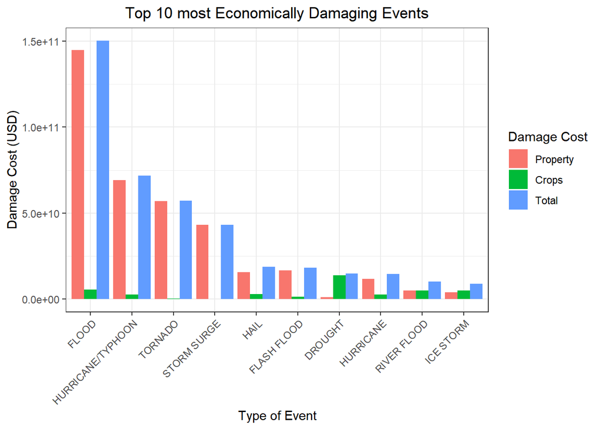

```r
# Creating the ggplot object for the plot
economicLoss <- ggplot(tCostMelt, aes(x = reorder(EVTYPE, -value), y = value))

# Adding the bar plot to the ggplot object
economicLoss <- economicLoss + geom_bar(stat = "identity",
                                        aes(fill = TypeOfDmg),
                                        position = "dodge")

# Adding labels to the y and x axes
economicLoss <- economicLoss + ylab("Damage Cost (USD)") + xlab("Type of Event")

# Adding a main title to the chart and centering it, and adding a white background
economicLoss <- economicLoss + ggtitle("Top 10 most Economically Damaging Events") + theme_bw() + theme(plot.title = element_text(hjust = 0.5))

# Modifying the legend title and labels
economicLoss <- economicLoss + scale_fill_discrete(name = "Damage Cost", labels = c("Property", "Crops", "Total"))

# Rotating the x-axis division-labels (by 45 degrees)
economicLoss <- economicLoss + theme(axis.text.x = element_text(angle = 45, hjust = 1))

# Printing the plot
print(economicLoss)
```

## Conclusion

Thus, it is clearly evident from the plotted graphs that **Tornadoes** claim the most human lives and have the highest injury rates, and **Floods** have the greatest economic consequences. (*mostly in terms of property damage*)